# Dia 2- Modelos de Markov para datos discretos

Rosana Zenil-Ferguson

2024-08-27

## Instala R y Rstudio (Posit Cloud)

Por favor instala en tu computadora

[figure not shown]

- Version gratuita para estudiantes

o si quieres trabajar online solo abre una cuenta de (tambien gratuita para estudiantes)

[figure not shown]

Posit Cloud

## Correr codigo en Rmarkdown

En cada seccion vas a encontrar texto y codigo. El codigo esta agregado entre entre tres acentos al reves y empieza con las llaves {r echo=TRUE}. Junto a esa linea vas a ver una flecha verde. Esa flecha ejecuta el codigo. Los archivos .Rmd son una herramienta muy util para reproducir el codigo. Son una combinacion de texto con codigo ejecutable y nos permiten crear un documento de manera eficiente donde todos los datos se pueden manejar.

## Lee el arbol y la filogenia

Los datos que vas a leer son datos de la polinizacion de Thalictrum con una filogenia de 103 especies. Vamos a generar el modelo de Markov y su estimacion utilizando los paquetes mas populares de R .

Por favor installa los siguientes paquetes (ejecuta con la flecha verde)

```r
#include=FALSE
#install.packages("ape")
#install.packages("geiger")
#install.packages("corHMM")
```

Y cargalos para poder empezar a analizar datos

```r
#Libraries required
library(ape)
library(geiger)
library(phytools)
library(corHMM)
```

## Lectura de los datos

Lo primero es saber donde tenemos guardamos nuestros archivos. Yo por ejemplo los tengo en este folder `~Dropbox/Teaching/Workshops/sureste2024`. La funcion `setwd()` nos ayuda a marcar el folder donde estaremos trabajando.

```r
## Leer los datos
setwd("~/Dropbox/Teaching/Workshops/sureste2024")
pollination_tree<-read.tree("poliniza_arbol.tre")
pollination_data<-read.csv("poliniza_datos.csv", header=TRUE)
head(pollination_data)
```

```
##        name pollination
## 1 species_1           0
## 2 species_2           0
## 3 species_3           0
## 4 species_4           0
## 5 species_5           0
## 6 species_6           0
```

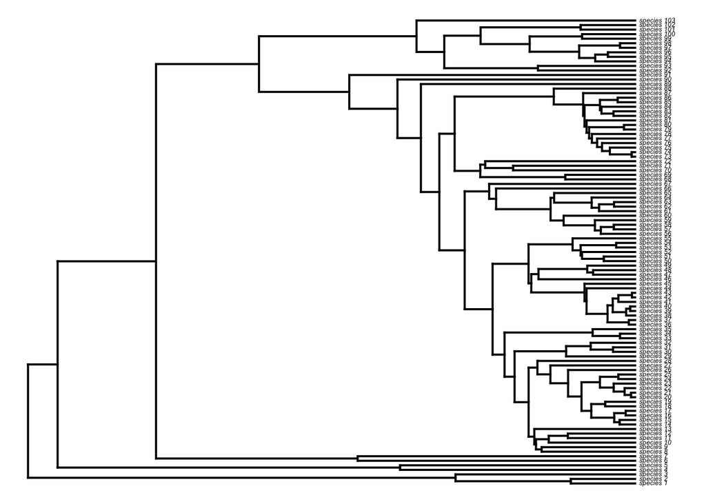

```r
## Graficar un arbol
plotTree(pollination_tree,fsize=0.4,ftype="i")
```

```r
## Graficar un arbol circular
#plotTree()
```

El paquete `phytools` requiere que los datos sean leidos como lista

```r
fmode<-setNames(pollination_data$pollination,pollination_data$name)
fmode
```

```
##   species_1   species_2   species_3   species_4   species_5   species_6
##           0           0           0           0           0           0
##   species_7   species_8   species_9  species_10  species_11  species_12
##           0           0           1           0           1           0
##  species_13  species_14  species_15  species_16  species_17  species_18
##           0           1           1           1           1           0
##  species_19  species_20  species_21  species_22  species_23  species_24
##           1           0           1           1           1           0
##  species_25  species_26  species_27  species_28  species_29  species_30
##           0           0           0           0           0           0
##  species_31  species_32  species_33  species_34  species_35  species_36
##           0           0           0           0           0           1
##  species_37  species_38  species_39  species_40  species_41  species_42
##           1           1           1           1           1           1
##  species_43  species_44  species_45  species_46  species_47  species_48
##           1           1           1           0           0           0
##  species_49  species_50  species_51  species_52  species_53  species_54
##           1           0           0           0           1           1
##  species_55  species_56  species_57  species_58  species_59  species_60
##           0           0           0           0           0           1
##  species_61  species_62  species_63  species_64  species_65  species_66
##           0           0           0           0           0           0
##  species_67  species_68  species_69  species_70  species_71  species_72
##           0           1           0           1           0           1
##  species_73  species_74  species_75  species_76  species_77  species_78
##           1           1           1           1           1           1
##  species_79  species_80  species_81  species_82  species_83  species_84
##           1           1           1           1           1           1
##  species_85  species_86  species_87  species_88  species_89  species_90
##           1           1           1           1           0           0
##  species_91  species_92  species_93  species_94  species_95  species_96
##           1           0           0           0           0           0
##  species_97  species_98  species_99 species_100 species_101 species_102
##           0           0           0           0           0           0
## species_103
##           0
```

Ahora grafiquemos los datos con el arbol filogenetico

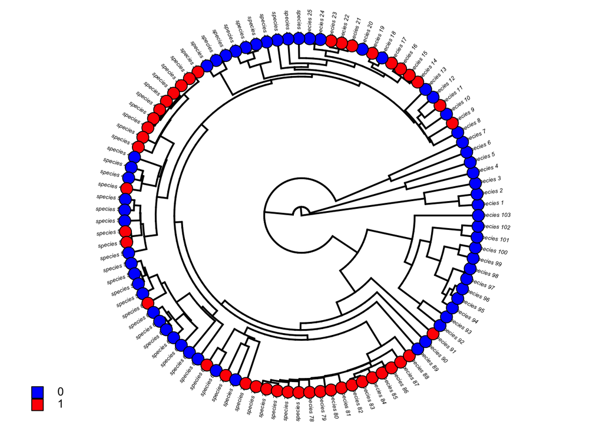

```r
plotTree(pollination_tree,fsize=0.4,ftype="i",type="fan")
cols<-setNames(c("blue","red"),sort(unique(fmode)))
tiplabels(pie=to.matrix(fmode,sort(unique(fmode))),piecol=cols,cex=0.5)
add.simmap.legend(colors=cols,prompt=FALSE,x=0.9*par()$usr[1],
    y=-max(nodeHeights(pollination_tree)),fsize=0.8)
```

## Utilizando los modelos de Markov

El modelo mas sencillo asume que las tasas de transicion entre 0 y 1 son iguales. Vamos a ajustarlo en estos datos

```r
# la variable fitER se refiere a "fit equal rates model" ajustar el model con tasas iguales para dos estados
fitER<-ace(fmode,pollination_tree,model="ER",type="discrete",C=TRUE)
fitER
```

```
##
##     Ancestral Character Estimation
##
## Call: ace(x = fmode, phy = pollination_tree, type = "discrete", CI = TRUE,
##     model = "ER")
##
##     Log-likelihood: -48.58381
##
## Rate index matrix:
##   0 1
## 0 . 1
## 1 1 .
##
## Parameter estimates:
##  rate index estimate std-err
##           1   0.0611  0.0154
##
## Scaled likelihoods at the root (type '...$lik.anc' to get them for all nodes):
##         0         1
## 0.7122289 0.2877711
```

```r
fitER$rates
```

```
## [1] 0.06112239
```

### Reconstruccion ancestral en los nodos

Ya que tenemos un modelo ajustado con estimadores de maxima verosimilitud, podemos reconstruir el pasado utilizando verosimilitudes marginales en cada nodo. A este grafico se le llama arbol con reconstruccion ancestral

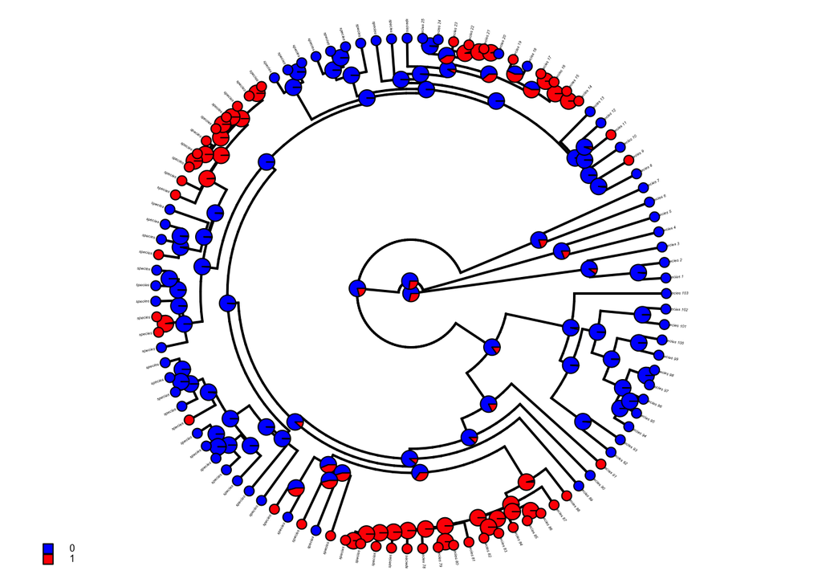

```r
plotTree(pollination_tree,type="fan",fsize=0.2,ftype="i")
nodelabels(node=1:pollination_tree$Nnode+Ntip(pollination_tree),
    pie=fitER$lik.anc,piecol=cols,cex=0.5)
tiplabels(pie=to.matrix(fmode,sort(unique(fmode))),piecol=cols,cex=0.3)
add.simmap.legend(colors=cols,prompt=FALSE,x=0.9*par()$usr[1],
    y=-max(nodeHeights(pollination_tree)),fsize=0.5)
```

Tambien podemos hacer simulaciones condicionales para saber lo que sucedio en las ramas. A este grafico se le llama mapa estocastico de reconstruccion ancestral

```r
mtree<-make.simmap(pollination_tree,fmode,model="ER")
```

```
## make.simmap is sampling character histories conditioned on
## the transition matrix
##
## Q =
##             0           1
## 0 -0.06112239  0.06112239
## 1  0.06112239 -0.06112239
## (estimated using likelihood);
## and (mean) root node prior probabilities
## pi =
##   0   1
## 0.5 0.5
```

```
## Done.
```

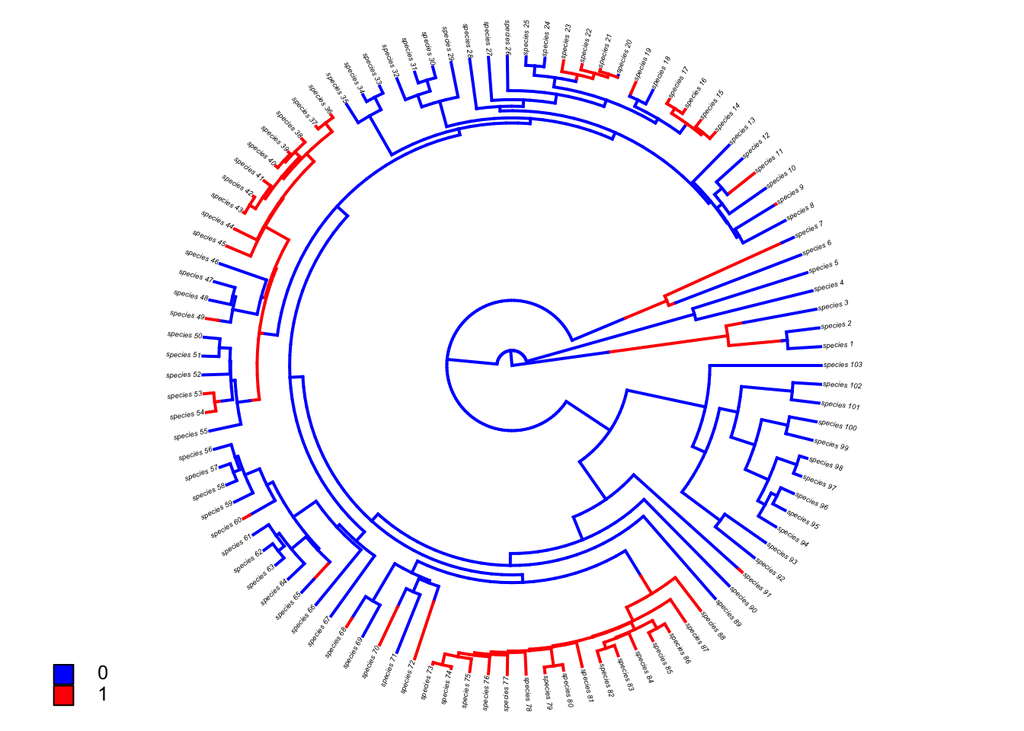

```r
plotSimmap(mtree,cols,type="fan",fsize=0.3,ftype="i")
add.simmap.legend(colors=cols,prompt=FALSE,x=0.9*par()$usr[1],
    y=-max(nodeHeights(pollination_tree)),fsize=0.8)
```

## Modelos de Markov con mas variabilidad

En macroevolucion no siempre podemos asumir que las transiciones entre dos estados (tasas evolutivas) ocurren al mismo paso. Ajustar un modelo mucho mas libre es en general una mejor opcion

```r
mk2<-corHMM(pollination_tree, pollination_data, rate.cat=1)
```

```
## State distribution in data:
## States:  1   2
## Counts:  59  44
## Beginning thorough optimization search -- performing 0 random restarts
## Finished. Inferring ancestral states using marginal reconstruction.
```

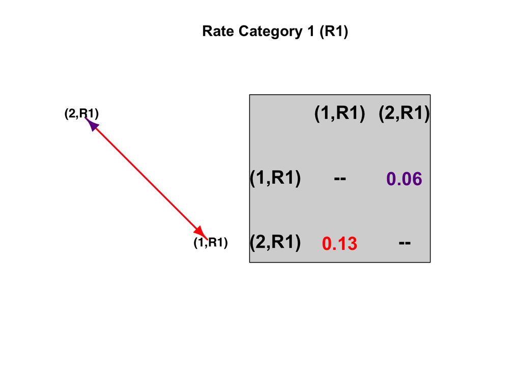

```r
plotMKmodel(mk2)
```

Como se ve el mapa estocastico?

```
## no colors provided. using the following legend:
##         0         1
##   "black" "#DF536B"
```

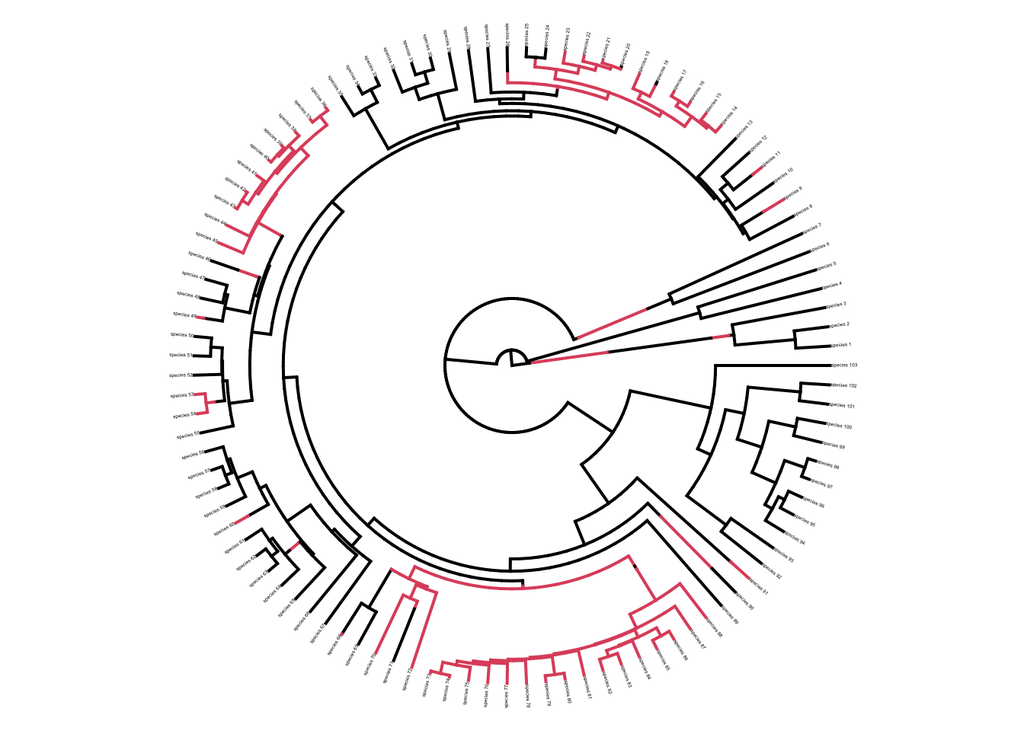

```r
phy= mk2$phy
data=mk2$data
model= mk2$solution
model[is.na(model)]=0
diag(model)= -rowSums(model)
simmap<-makeSimmap (tree=phy, data=data, model=model, rate.cat=1, nSim=1, nCores=1)
plotSimmap(simmap[[1]], fsize=0.2, type="fan")
```

### Modelos con estados escondidos

En evolucion, a traves de millones de años debemos pensar en la posibilidad de que las tasas de transicion ocurren a differentes pasos. Para esto utilizamos modelos de Markov de estados escondidos.

```r
mk2_hidden<-corHMM(pollination_tree, pollination_data, rate.cat=2,model="ARD")
```

```
## State distribution in data:
## States:  1   2
## Counts:  59  44
## Beginning thorough optimization search -- performing 0 random restarts
## Finished. Inferring ancestral states using marginal reconstruction.
```

[figure not shown]

```r
plotMKmodel(mk2_hidden)
```

Como se ve el mapa estocastico?

```
## no colors provided. using the following legend:
##    (0,R1)    (0,R2)    (1,R1)    (1,R2)
##   "black" "#DF536B" "#61D04F" "#2297E6"
```

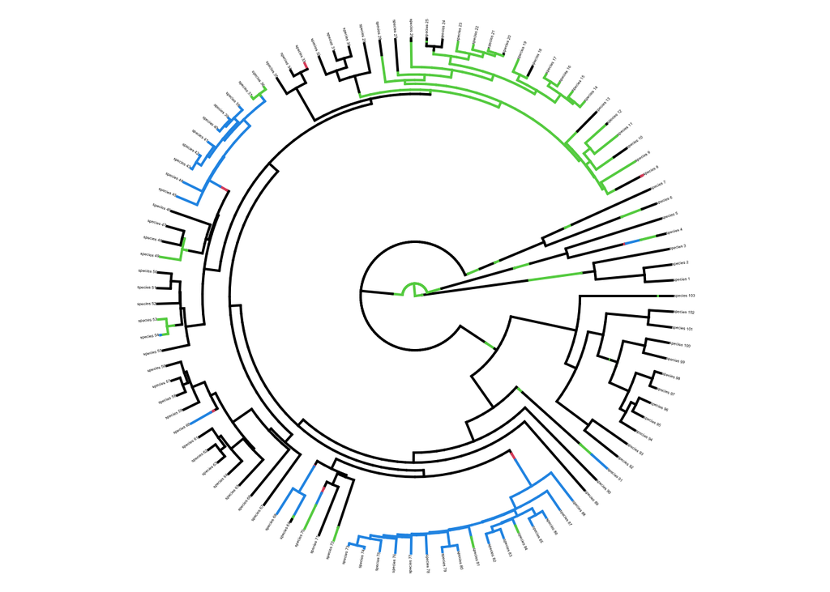

```r
phy= mk2_hidden$phy
data=mk2_hidden$data
model= mk2_hidden$solution
model[is.na(model)]=0
diag(model)= -rowSums(model)
simmap<-makeSimmap (tree=phy, data=data, model=model, rate.cat=2, nSim=1, nCores=1)
plotSimmap(simmap[[1]], fsize=0.2, type="fan")
```